# Projet final du Kit Data Science 2021

Le projet final du Kit Data Science 2021 porte sur les données du Vendée Globe 2020-2021.

Le projet se déroule 26 octobre au 5 novembre 2021 date limite pour rendre vos projets respectifs.

Les données du dernier Vendée Globe sont disponibles sous la forme de fichiers Excel avec les classements fournis plusieurs fois par jour par les organisateurs de la course. Il y a également une page web avec une fiche technique par voilier qui contient des informations techniques et qu'il est possible de rapprocher des classements.

Il vous appartient de charger les données en Python, de procéder aux préparations nécessaires et d'effectuer les analyses pertinentes de votre choix.

Le rendu sera un notebook Jupyter fourni aux formats ipynb et HTML.

#### Barème sur 15 points :

- Acquisition et chargement des données : 3 points
- Préparation des données : 5 points
- Analyses et story telling : 7 points

#### Exemples de traitements et d'analyses :

- Récupération des fichiers Excel avec les classements
  - Mettre en place une copie locale des fichiers Excel afin de ne pas les recharger à chaque run.
  - Vers la fin de la course le format des fichiers Excel change avec les arrivées des voiliers : il est possible de s'arrêter juste avant.
- Extraction des caractéristiques techniques de chacun des voiliers.
- Rapprochement des données des voiliers avec celle des classements.
- Visualisation de la distance parcourue par voilier.
- Cartes avec les routes d'un ou plusieurs voiliers.
- Corrélation et régression linéaire entre le classement (rang) et la vitesse utile (VMG) des voiliers.
- Analyses de séries temporelles.
- Application d'algorithmes statistiques ou de machine learning.
- etc.

#### Sources des données

- Page web donnant accès aux fichiers Excel des classements du Vendée Globe : https://www.vendeeglobe.org/fr/classement
- Page web avec les fiches techniques des voiliers du Vendée Globe : https://www.vendeeglobe.org/fr/glossaire
- Site web donnant accès à des fichiers avec les formes géométriques des côtes : https://www.naturalearthdata.com/ (ou bien utilisez les librairies plotly ou ipyleaflet pour produire des cartes)
- etc.

#### Questions/Réponses

Les questions et réponses seront publiées ci-après au fil de l'eau :

- Qu'est-ce qu'un foil ? https://www.vendeeglobe.org/fr/actualites/19755/quels-foils-pour-gagner-le-vendee-globe La présence d'un foil est indiqué dans l'attribut "Nombre de dérives" dans les fiches techniques des voiliers.
- S'agit-il d'un travail individuel ou collectif ? Il s'agit bien d'un travail individuel.

#### Avertissement

Vous devez publier votre notebook exécuté aux formats ipynb et HTML sur votre github avant le vendredi 5 novembre 2021 à 23h59 et lorsque c'est fait envoyer une notification par email avec le lien du projet à l'adresse contact@yotta-conseil.fr

```python
# maths
import random
from sklearn.linear_model import LinearRegression
import math as m

# librairies standard
import pandas as pd
import numpy as np
import requests

# graphique
import matplotlib.pyplot as plt
import seaborn as sns
from plotly.offline import init_notebook_mode, iplot
import folium
from branca.element import Figure

# divers
import subprocess
from bs4 import BeautifulSoup
import io
from os import listdir
from datetime import datetime
import time
import re
```

# I. Collecte des données et création d'un Dataset global

### 1.1 Import des caractéristiques des voiliers

```python
# génération d'une liste permettant de remplacer les mois en français en chiffres.
months = ['janvier', 'février', 'mars', 'avril', 'mai', 'juin', 'juillet', 'août',
             'septembre', 'octobre', 'novembre', 'décembre']


# fonction de modification du format de la date
def chang_date(val):
    i = months.index(val.split(" ")[1].lower())
    if i<10:
        return val.split(" ")[0]+'/0'+str(i+1)+'/'+val.split(" ")[2]
    else:
        return val.split(" ")[0]+'/'+str(i+1)+'/'+val.split(" ")[2]

# passage en valeurs numériques des colonnes adaptées
def chang_num(ser):
    a = ser.str.replace('m2','')
    a = a.str.replace('²','')
    a = a.str.replace('[a-zA-Z]','')
    a = a.str.replace(',','.')
    a = pd.to_numeric(a)
    return a

# nettoyage de la colonne No de voile, utilisée pour le merge par la suite
def chang_nam(x):
    if len(x) == 1:
        x = '0'+x
    if len(x)<=3:
        x = 'FRA ' + x
    if x[3]!=' ':
        x = x[:3]+' '+x[3:]
    if x[-2] == ' ':
        x = x[:-1] + '0' + x[-1]
    return x

# fonction générale de récupération des caractéristiques des voiliers
def gloss(url):
    soup = BeautifulSoup(requests.get(url).content)
    ww = soup.findAll('div', attrs={'class': 'boats-list__popup mfp-hide'})
    param = ['Numéro de voile', 'Anciens noms du bateau', 'Architecte', 'Chantier',
             'Date de lancement', 'Longueur', 'Largeur', 'Tirant d\'eau', 'Déplacement (poids)',
             'Nombre de dérives', 'Hauteur mât', 'Voile quille', 'Surface de voiles au près',
             'Surface de voiles au portant']
    name = []
    g = {i : [] for i in param}
    for i in ww:
        name.append(i.find('h3').text)
        carac = {u.text.split(":")[0].strip(): u.text.split(":")[1].strip() for u in i.select('li')}
        for j in g:
            if j in carac:
                g[j].append(carac[j])
            else:
                g[j].append(np.nan)

    dataset = pd.DataFrame(g, index=name)

    for c in ['Longueur', 'Largeur','Tirant d\'eau', 'Déplacement (poids)', 'Hauteur mât',
             'Surface de voiles au près', 'Surface de voiles au portant']:
        dataset[c] = chang_num(dataset[c])

    dataset['Date de lancement'] = pd.to_datetime(dataset['Date de lancement'].apply(chang_date))
    return dataset

# Chargement des fichiers
URL = 'https://www.vendeeglobe.org/fr/glossaire'
dfg = gloss(URL)

# nettoyage du dfg
dfg['Numéro de voile'] = dfg['Numéro de voile'].fillna('FRA 59')
dfg['Numéro de voile'] = dfg['Numéro de voile'].apply(chang_nam)
dfg = dfg.rename({'Numéro de voile': 'Voile'}, axis=1)

# sauvegarde dans le dossier dataset
output = 'dataset/'+'df_gloss_'+datetime.now().strftime("%Y%m%d-%H%M%S")+'.csv'
dfg.to_csv(output)
print('sauvegarde du fichier glossaire à dataset/%s' % output)
```

```
sauvegarde du fichier glossaire à dataset/dataset/df_gloss_20211104-225409.csv
```

```python
dfg
```

|  | Voile | Anciens noms du bateau | Architecte | Chantier | Date de lancement | Longueur | Largeur | Tirant d'eau | Déplacement (poids) | Nombre de dérives | Hauteur mât | Voile quille | Surface de voiles au près | Surface de voiles au portant |
| --- | --- | --- | --- | --- | --- | --- | --- | --- | --- | --- | --- | --- | --- | --- |
| NEWREST - ART & FENÊTRES | FRA 56 | No Way Back, Vento di Sardegna | VPLP/Verdier | Persico Marine | 2015-01-08 | 18.28 | 5.85 | 4.5 | 7.0 | foils | 29.0 | monotype | 320 | 570 |
| PURE - Best Western® | FRA 49 | Gitana Eighty, Synerciel, Newrest-Matmut | Bruce Farr Design | Southern Ocean Marine (Nouvelle Zélande) | 2007-08-03 | 18.28 | 5.80 | 4.5 | 9.0 | 2 | 28.0 | acier forgé | 280 | 560 |
| TSE - 4MYPLANET | FRA 72 | Famille Mary-Etamine du Lys, Initiatives Coeur... | Marc Lombard | MAG France | 1998-01-03 | 18.28 | 5.54 | 4.5 | 9.0 | 2 | 29.0 | acier | 260 | 580 |
| Maître CoQ IV | FRA 17 | Safran 2 - Des Voiles et Vous | Verdier - VPLP | CDK Technologies | 2015-12-03 | 18.28 | 5.80 | 4.5 | 8.0 | foils | 29.0 | acier mécano soudé | 310 | 550 |
| CHARAL | FRA 08 | NaN | VPLP | CDK Technologies | 2018-08-18 | 18.28 | 5.85 | 4.5 | 8.0 | foils | 29.0 | acier | 320 | 600 |
| LA MIE CÂLINE - ARTISANS ARTIPÔLE | FRA 14 | Ecover3, Président, Gamesa, Kilcullen Voyager-... | Owen Clarke Design LLP - Clay Oliver | Hakes Marine - Mer Agitée | 2007-03-08 | 18.28 | 5.65 | 4.5 | 7.9 | foils | 29.0 | basculante avec vérin | 300 | 610 |
| BUREAU VALLEE 2 | FRA 18 | Banque Populaire VIII | Verdier - VPLP | CDK Technologies | 2015-09-06 | 18.28 | 5.80 | 4.5 | 7.6 | foils | 28.0 | acier | 300 | 600 |
| ONE PLANET ONE OCEAN | ESP 33 | Kingfisher - Educacion sin Fronteras - Forum M... | Owen Clarke Design | Martens Yachts | 2000-02-02 | 18.28 | 5.30 | 4.5 | 8.9 | 2 | 26.0 | acier | 240 | 470 |
| GROUPE SÉTIN | FRA 71 | Paprec-Virbac2, Estrella Damm, We are Water, L... | Bruce Farr Yacht Design | Southern Ocean Marine (Nouvelle-Zélande) | 2007-02-02 | 18.28 | 5.80 | 4.5 | 9.0 | 2 asymétriques | 28.5 | basculante sur vérin hydraulique | 270 | 560 |
| BANQUE POPULAIRE X | FRA 30 | Macif - SMA | Verdier - VPLP | CDK - Mer Agitée | 2011-01-03 | 18.28 | 5.70 | 4.5 | 7.7 | 2 | 29.0 | acier forgé | 340 | 570 |
| APIVIA | FRA 79 | NaN | Verdier | CDK technologies - MerConcept | 2019-05-08 | 18.28 | 5.85 | 4.5 | 8.0 | foils | 29.0 | acier | 350 | 560 |
| INITIATIVES-COEUR | FRA 109 | Maître CoQ - Banque Populaire VII- Foncia II | VPLP - Verdier | CDK Technologies | 2010-09-20 | 18.28 | 5.70 | 4.5 | 7.8 | foils | 27.0 | acier forgé | 300 | 600 |
| MERCI | FRA 69 | Foresight Natural Energy, Maisonneuve | Lavanos | Artech do Brasil | 2005-01-15 | 18.28 | 5.60 | 4.5 | 8.5 | 2 | 29.0 | acier | 250 | 650 |
| OMIA - WATER FAMILY | FRA 09 | Spirit of Yukoh, Neutrogena, Hugo Boss, Estrel... | Bruce Farr Design | Offshore Challenge - Cowes | 2007-03-07 | 18.28 | 5.85 | 4.5 | 8.0 | 2 | 29.0 | acier forgé | 300 | 700 |
| PRB | FRA 85 | NaN | Verdier - VPLP | CDK Technologies | 2010-08-03 | 18.28 | 5.50 | 4.5 | NaN | foils | 27.4 | Acier mécano soudé | 300 | 600 |
| Compagnie du Lit / Jiliti | FRA 83 | Delta Dore, Bureau Vallée, Vers un Monde sans ... | Bruce Farr design | JMV Cherbourg | 2006-07-26 | 18.28 | 5.75 | 4.5 | 8.5 | 2 | 29.0 | acier forgé | 300 | 620 |
| MEDALLIA | GBR 77 | Armor Lux, We Are Water, La Fabrique | Pierre Rolland | Bernard Stamm | 1999-03-07 | 18.28 | 5.70 | 4.5 | 9.0 | 2 | 29.0 | carbone | 300 | 580 |
| SEAEXPLORER - YACHT CLUB DE MONACO | FRA 16 | Edmond de Rothschild, Malizia - Yacht Club de ... | Verdier - VPLP | Multiplast | 2015-07-08 | 18.28 | 5.70 | 4.5 | 7.6 | foils | 29.0 | acier | 290 | 490 |
| STARK | FIN 222 | Aviva, GAES Centros Auditivos | Owen Clarke Design | Hakes Marine - Wellington (Nouvelle-Zélande) | 2007-06-08 | 18.28 | 5.80 | 4.5 | 8.5 | 2 | 28.0 | acier | 270 | 580 |
| MACSF | FRA 27 | Quéguiner, Safran | Verdier - VPLP | Chantier Naval de Larros | 2007-04-07 | 18.28 | 5.60 | 4.5 | 7.7 | foils | 27.0 | acier | 300 | 650 |
| Yes We Cam! | FRA 001 | Cheminées Poujoulat, Mare, Maître CoQ, Mapfre,... | Bruce Farr design | CDK Technologies | 2007-03-01 | 18.28 | 5.90 | 4.5 | 8.0 | 2 | 28.0 | acier forgé | 300 | 620 |
| TIME FOR OCEANS | FRA 92 | Hugo Boss, Energa, Compagnie du Lit-Boulogne B... | Finot-Conq Design | Neville Hutton | 2007-01-06 | 18.28 | 5.84 | 4.5 | 8.5 | foils | 28.0 | monotype | 300 | 550 |
| CAMPAGNE DE FRANCE | FRA 50 | Great America IV, Mirabaud, Temenos | Owen Clarke | Southern Ocean Marine, Tauranga | 2006-04-05 | 18.28 | 5.50 | 4.5 | 8.5 | 2 | 28.0 | carbone | 330 | 600 |
| PRYSMIAN GROUP | ITA 34 | Saint-Michel - Virbac | VPLP - Verdier | Multiplast | 2015-02-04 | 18.28 | 5.80 | 4.5 | 8.0 | foils | 29.0 | acier forgé | 300 | 600 |
| LA FABRIQUE | SUI 07 | Brit Air, Votre Nom autour du Monde, MACSF | Groupe Finot-Conq | Multiplast | 2007-01-08 | 18.28 | 5.90 | 4.5 | NaN | foils | 27.0 | carbone | 290 | 580 |
| LinkedOut | FRA 59 | NaN | Verdier | Persico | 2019-03-09 | 18.28 | 5.85 | 4.5 | 8.0 | foils | 29.0 | acier forgé | 350 | 560 |
| GROUPE APICIL | FRA 1000 | Comme Un Seul Homme, DCNS | Groupe Finot-Conq | Multiplast | 2008-10-08 | 18.28 | 5.85 | 4.5 | 8.5 | 2 | 29.0 | acier forgé | 350 | 610 |
| DMG MORI Global One | JPN 11 | NaN | VPLP | Multiplast | 2019-05-09 | 18.28 | 5.85 | 4.5 | 8.0 | foils | 29.0 | acier forgé | 320 | 580 |
| ARKEA PAPREC | FRA 04 | NaN | Juan Kouyoumdjian | CDK Technologies / Assemblage | 2019-07-19 | 18.28 | 5.70 | 4.5 | 8.0 | foiler | 29.0 | Inox usiné | 260 | 600 |
| V and B-MAYENNE | FRA 53 | Le Souffle du Nord, Groupe Bel | Verdier - VPLP | Indiana Yachting (Scarlino, Italie) | 2007-07-09 | 18.28 | 5.50 | 4.5 | 7.7 | 2 | 29.0 | acier | 365 | 700 |
| HUGO BOSS | GBR 99 | NaN | VPLP - Alex Thomson Racing (led by Pete Hobson) | Carrington Boats | 2019-08-15 | 18.28 | 5.40 | 4.5 | 7.7 | foils | 29.0 | acier forgé | 330 | 630 |
| L'OCCITANE EN PROVENCE | FRA 02 | NaN | Samuel Manuard | Black Pepper© | 2020-01-31 | 18.28 | 5.50 | 4.5 | 7.8 | foils | 28.0 | acier forgé | 270 | 535 |
| CORUM L'EPARGNE | FRA 06 | NaN | Juan Kouyoumdjian | CDK technologies - Mer Agitée | 2020-05-15 | 18.28 | 5.70 | 4.5 | 7.9 | foils | 27.3 | NaN | 270 | 535 |

### 1.2 Téléchargement des fichiers journaliers de classement

On parse l'url permettant d'obtenir les classements pour récupérer les noms exacts des fichiers excels de classement. Une fois réalisé, on utilise la fonction subprocess qui permet de lancer des commandes linux via le jupyter notebook (fonction cmdsh définie ci-dessous).

```python
#fonction de commande linux
def cmdsh(cmd):
    try:
        output = subprocess.check_output(cmd, shell=True, universal_newlines=True, stderr= subprocess.STDOUT)
    except subprocess.CalledProcessError as exc:
        print("Status : FAIL", exc.returncode, exc.output)

# lecture des noms des fichiers .xlsx par scrapping de la page du VendéeGlobe:
p0='https://www.vendeeglobe.org/fr/classement'
soup = BeautifulSoup(requests.get(p0).content)
dat = soup.find('select', attrs={'class': 'form__input m--select onsubmit-rank'})
val = dat.find_all('option')
fichiers = ['https://www.vendeeglobe.org/download-race-data/'+"vendeeglobe_"+i['value']+".xlsx"
          for i in val if len(i['value'])>0]
```

```python
# commande de téléchargement des fichiers
compteur = 1
for i in fichiers:
    print(f'téléchargement - progression {(compteur*100)//len(fichiers)}%\r', end='')
    cmdsh("wget -P data/ "+i)
    compteur +=1
print()
```

```
téléchargement - progression 100%
```

### 1.3 Compilation des dataset de caractéristiques et de classements

On crée à partir de chaque fichier excel ouvert un DataFrame temporaire (dfj) qui est ajouté à la liste des tous les dataframes. Une fois cette opération réalisée, on fusionne tous les dataframe temporaires dans le dataframe final (df) puis on fait un merge avec le dataframe du glossaire à partir de la colonne 'Voile'. Les coordonnées en DMS sont transformées en degré décimal. Enfin, les horaires sont obtenues à partir du nom du fichiers.

```python
# recherche du dernier fichier à charger avant l'arrivée du premier de la course ('data/20210127_140000.xlsx')
# ouverture de chaque fichier de classement enregistré
fichiers = ['data/'+i for i in listdir('data/')]
last_index = fichiers.index('data/20210127_140000.xlsx')
start = time.time()
dataset=[]
compteur = 1
for fichier in fichiers[:last_index+1]:
    print(f'ouverture des tableaux - progression {(compteur*100)//last_index}%\r', end='')
    dfj = pd.read_excel(fichier)
    dfj = dfj[:-3]
    dat_ = fichier[5:-5]
    GDH = dat_[:4]+'-'+dat_[4:6]+'-'+dat_[6:8]+'T'+dat_[9:11]+':'+dat_[11:13]+':'+dat_[13:15]
    dfj['Unnamed: 0'] = datetime.fromisoformat(GDH)
    dfj = dfj[4:-4]
    dataset.append(dfj)
    compteur +=1
print()

print('compilation')
df = pd.concat(dataset)

# nettoyage
df.columns = ['GDH', 'Rang', 'Voile', 'Skipper/Bateau', 'Heure', 'Lat', 'Long',
         'Cap_30', 'Vitesse_30', 'VMG_30', 'Distance_30',
         'Cap_last', 'Vitesse_last', 'VMG_last', 'Distance_last',
         'Cap_24', 'Vitesse_24', 'VMG_24', 'Distance_24',
         'DTF', 'DTL']
df['Voile'].str.replace('FR\n','').str.replace('\n','')
df = df.reset_index()
del df['index']
df['Voile'] = df['Voile'].str.split('\n').apply(lambda x: x[-1])
df['Voile'] = df['Voile'].apply(chang_nam)

# fonction de converstion des coordonnées: passage de deg/min à degré décimal:
def convert(x):
    deg, minutes, direction = re.split('[°\'"]', x)
    return (float(deg) + float(minutes)/60)*(-1 if direction in ['W', 'S'] else 1)

df['Lat'] = df['Lat'].apply(lambda x: x if pd.isnull(x) else convert(x))
df['Long'] = df['Long'].apply(lambda x: x if pd.isnull(x) else convert(x))

# merge avec le glossaire:
df = pd.merge(df, dfg, left_on='Voile', right_on='Voile', how='left')

# Sauvegarde
output = 'dataset/'+'df_class_'+datetime.now().strftime("%Y%m%d-%H%M%S")+ '.csv'
df.to_csv(output)
print('dataset sauvegardé à dataset/%s -- temps total:%3.fs' % (output, (time.time()-start)))
```

```
ouverture des tableaux - progression 100%
compilation
dataset sauvegardé à dataset/dataset/df_class_20211104-143725.csv -- temps total: 36s
```

```python
# Si nécessité de charger le dernier dataframe global compilé:
output = 'dataset/'+[l for l in listdir('dataset/') if l[3] == 'c'][-1]
df=pd.read_csv(output,index_col=0)
```

```python
df
```

|  | GDH | Rang | Voile | Skipper/Bateau | Heure | Lat | Long | Cap_30 | Vitesse_30 | VMG_30 | ... | Date de lancement | Longueur | Largeur | Tirant d'eau | Déplacement (poids) | Nombre de dérives | Hauteur mât | Voile quille | Surface de voiles au près | Surface de voiles au portant |
| --- | --- | --- | --- | --- | --- | --- | --- | --- | --- | --- | --- | --- | --- | --- | --- | --- | --- | --- | --- | --- | --- |
| 0 | 2020-11-08 12:02:00 | NaN | FRA 79 | Charlie Dalin\nAPIVIA | NaN | NaN | NaN | NaN | NaN | NaN | ... | 2019-05-08 | 18.28 | 5.85 | 4.5 | 8.0 | foils | 29.0 | acier | 350.0 | 560.0 |
| 1 | 2020-11-08 12:02:00 | NaN | FRA 04 | Sébastien Simon\nARKEA PAPREC | NaN | NaN | NaN | NaN | NaN | NaN | ... | 2019-07-19 | 18.28 | 5.70 | 4.5 | 8.0 | foiler | 29.0 | Inox usiné | 260.0 | 600.0 |
| 2 | 2020-11-08 12:02:00 | NaN | FRA 30 | Clarisse Cremer\nBanque Populaire X | NaN | NaN | NaN | NaN | NaN | NaN | ... | 2011-01-03 | 18.28 | 5.70 | 4.5 | 7.7 | 2 | 29.0 | acier forgé | 340.0 | 570.0 |
| 3 | 2020-11-08 12:02:00 | NaN | FRA 18 | Louis Burton\nBureau Vallée 2 | NaN | NaN | NaN | NaN | NaN | NaN | ... | 2015-09-06 | 18.28 | 5.80 | 4.5 | 7.6 | foils | 28.0 | acier | 300.0 | 600.0 |
| 4 | 2020-11-08 12:02:00 | NaN | FRA 50 | Miranda Merron\nCampagne de France | NaN | NaN | NaN | NaN | NaN | NaN | ... | 2006-04-05 | 18.28 | 5.50 | 4.5 | 8.5 | 2 | 28.0 | carbone | 330.0 | 600.0 |
| ... | ... | ... | ... | ... | ... | ... | ... | ... | ... | ... | ... | ... | ... | ... | ... | ... | ... | ... | ... | ... | ... |
| 14485 | 2021-01-27 14:00:00 | RET | FRA 69 | Sébastien Destremau\nMerci | NaN | NaN | NaN | NaN | NaN | NaN | ... | 2005-01-15 | 18.28 | 5.60 | 4.5 | 8.5 | 2 | 29.0 | acier | 250.0 | 650.0 |
| 14486 | 2021-01-27 14:00:00 | RET | FRA 27 | Isabelle Joschke\nMACSF | NaN | NaN | NaN | NaN | NaN | NaN | ... | 2007-04-07 | 18.28 | 5.60 | 4.5 | 7.7 | foils | 27.0 | acier | 300.0 | 650.0 |
| 14487 | 2021-01-27 14:00:00 | RET | FRA 56 | Fabrice Amedeo\nNewrest - Art et Fenetres | NaN | NaN | NaN | NaN | NaN | NaN | ... | 2015-01-08 | 18.28 | 5.85 | 4.5 | 7.0 | foils | 29.0 | monotype | 320.0 | 570.0 |
| 14488 | 2021-01-27 14:00:00 | RET | FRA 109 | Samantha Davies\nInitiatives - Coeur | NaN | NaN | NaN | NaN | NaN | NaN | ... | 2010-09-20 | 18.28 | 5.70 | 4.5 | 7.8 | foils | 27.0 | acier forgé | 300.0 | 600.0 |
| 14489 | 2021-01-27 14:00:00 | RET | FRA 04 | Sébastien Simon\nARKEA PAPREC | NaN | NaN | NaN | NaN | NaN | NaN | ... | 2019-07-19 | 18.28 | 5.70 | 4.5 | 8.0 | foiler | 29.0 | Inox usiné | 260.0 | 600.0 |

14490 rows × 34 columns

# II. Visualisation des distances et routes

### 2.1 Etude de la distance cumulée par voilier

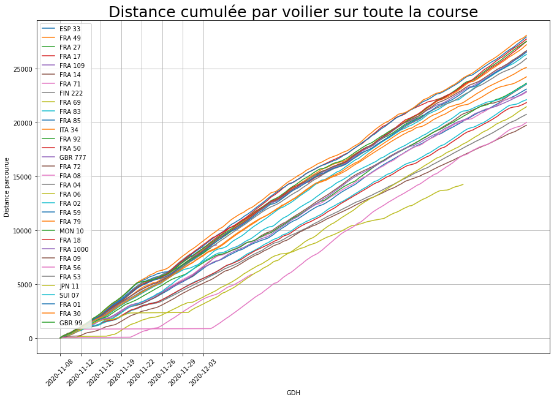

```python
# visualisation de la distance cumulée par voilier:
df0 = df[['Voile', 'GDH', 'Distance_last']]
df0 = df0.dropna()
df0['Distance_last'] = pd.to_numeric(df0['Distance_last'].str.replace('nm', ''))
# on retire les valeurs de départ qui semblent erronées (environ 2800 )
df0 = df0.loc[df0['Distance_last']<2000].groupby(['Voile', 'GDH']).agg({'Distance_last':'sum'})

# représentation graphique
plt.figure(figsize=(15,10))
for i in set(df['Voile']):
    plt.plot(df0.loc[i].index, df0.loc[i].cumsum(), label = i)
plt.xlabel('GDH')
plt.ylabel('Distance parcourue')
plt.xticks(df0.loc[i].index[::21], rotation = 45)
plt.legend()
plt.grid()
plt.title('Distance cumulée par voilier sur toute la course', size = 25)
plt.show()
```

### 2.2 Visualisation des routes empruntées

On utilise pour le tracé la librairie folium qui permet de présenter une carte interactive du monde. Le tracé des routes nécessite de découper la liste des coordonnées, les longitudes passant brusquement de 180° à -180°.

```python
# split des coordonnées des trajets selon les longitudes (passage de 180 à -180)
    # pour éviter le tracé d'une barre horizontale
def split_coord(c):
        s=0
        for i in range(len(c)-1):
            if (c[i][1]>170) and (c[i+1][1])<0:
                s=i
        return s+1

# fonction qui affiche la route de la liste des numéros de voiles fournie:
def traj_voil(list_voil):
    fig=Figure(height=500,width=1000)
    m = folium.Map(location = [-5, 0], zoom_start=2)
    fig.add_child(m)

    # génération de couleurs aléatoires
    coul = []
    for j in range(len(list_voil)):
        coul.append("#"+''.join([random.choice('ABCDEF0123456789') for i in range(6)]))

    compteur=0
    lgd_txt = '<span style="color: {col};">{txt}</span>'
    for i in list_voil:
        coord = list(zip(df.loc[df['Voile'] == i]['Lat'].dropna(),df.loc[df['Voile'] == i]['Long'].dropna()))
        f=folium.FeatureGroup(name= lgd_txt.format( txt= i, col= coul[compteur]))
        if split_coord(coord)>0:
            trajet1=folium.vector_layers.PolyLine(coord[:split_coord(coord)], popup='<b>trajet de '+i+'</b>',
                                                  color=coul[compteur],tooltip=i,weight=1).add_to(f)
            trajet2=folium.vector_layers.PolyLine(coord[split_coord(coord):], popup='<b>trajet de '+i+'</b>',
                                                  color=coul[compteur],tooltip=i,weight=1).add_to(f)
        else:
            trajet=folium.vector_layers.PolyLine(coord, popup='<b>trajet de '+i+'</b>',
                                                  color=coul[compteur],tooltip=i,weight=1).add_to(f)
        f.add_to(m)
        compteur+=1
    folium.map.LayerControl('topleft', collapsed= False).add_to(m)
    return m
```

```python
# routes des deux premiers de la course
traj_voil(['FRA 17', 'FRA 79', 'FRA 18'])
```

[interactive chart not shown]

```python
# route de tous les voiliers participants à la course:
traj_voil(set(df['Voile']))
```

[interactive chart not shown]

# III. Analyse mathématique

### 3.1 Regression linéaire

```python
# Corrélation entre le rang et la vitesse VMG. On prendra VMG_last qui est la moyenne
# de la vitesse de rapprochement au but sur la période courant depuis le dernier relevé de mesures

df1 = df[['Voile', 'VMG_last', 'Rang']]
df1 = df1.replace('RET', np.nan).dropna()
df1.loc[:,'VMG_last'] = pd.to_numeric(df1['VMG_last'].str.replace('kts', ''))
df1.loc[:, 'Rang'] = pd.to_numeric(df1['Rang'])
```

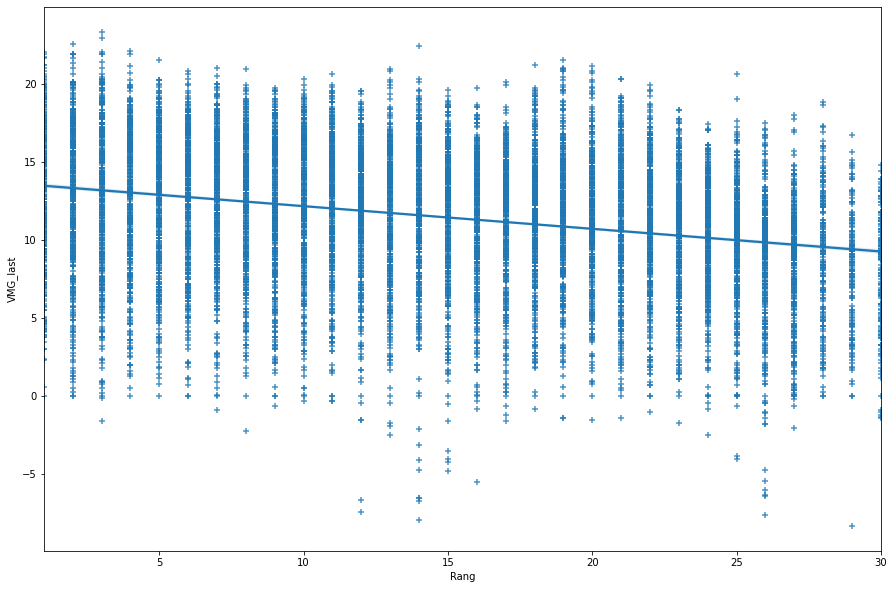

```python
# Visualisation simple de la régression linéaire via seaborn
plt.figure(figsize = (15,10))
sns.regplot(x=df1['Rang'], y=df1['VMG_last'],marker = '+');
```

```python
# Calcul mathématique à l'aide de LinearRegression de ScikitLearn:
X = np.array(df1['Rang']).reshape(-1,1)
y = np.array(df1['VMG_last']).reshape(-1,1)
reg = LinearRegression().fit(X,y)
print('coefficient de régression linéaire: %f\nintercept: %f\ncoef de corrélation: %2.1f%%' % (reg.coef_[0], reg.intercept_,
                                                                               m.sqrt(reg.score(X,y))*100))
```

```
coefficient de régression linéaire: -0.144911
intercept: 13.606560
coef de corrélation: 27.5%
```

Le coefficient négatif obtenu est bien logiquement conforme à l'observation visuelle faite, à savoir que le rang augmente lorsque la vitesse diminue. Toutefois, le résultat obtenu en terme de score est médiocre (27.5%) ce qui est normal vu la dispersion constaté sur le graphique supra. Il est alors plus judicieux de prendre une moyenne du classement selon le numéro de voile:

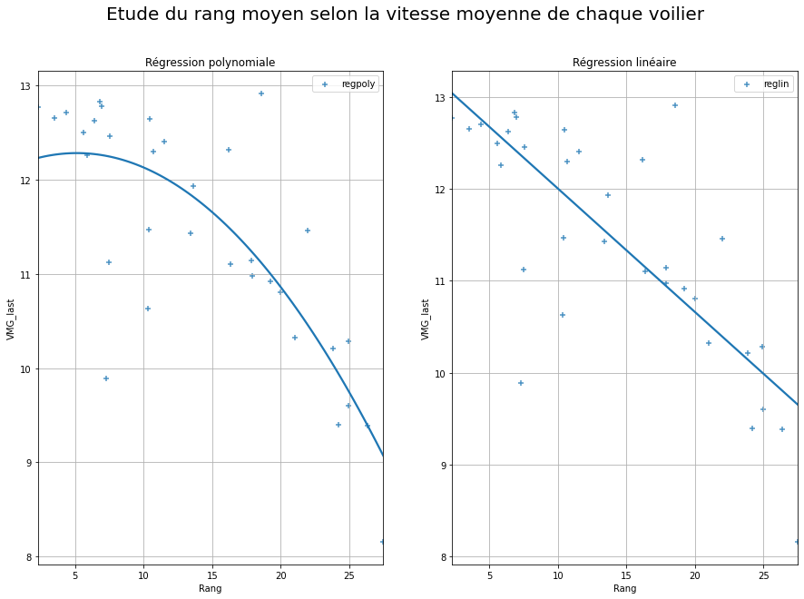

```python
# Approche visuelle en utilisant une régression polynomiale:
df2 = df1.groupby('Voile').agg({'Rang': 'mean', 'VMG_last': 'mean'})
plt.figure(figsize=(15,10))
plt.suptitle('Etude du rang moyen selon la vitesse moyenne de chaque voilier', size=20)
plt.subplot(121)
sns.regplot(x=df2['Rang'], y=df2['VMG_last'], marker = '+',order = 2, label='regpoly', ci=None)
plt.legend()
plt.grid()
plt.title('Régression polynomiale')
plt.subplot(122)
sns.regplot(x=df2['Rang'], y=df2['VMG_last'], marker = '+',order = 1,
            label = 'reglin', ci=None, robust = True)
plt.legend()
plt.grid()
plt.title('Régression linéaire')
plt.show()
```

```python
# approche mathématique en restant sur le modèle linéaire:
X = np.array(df2['Rang']).reshape(-1,1)
y = np.array(df2['VMG_last']).reshape(-1,1)
reg = LinearRegression().fit(X,y)
print('coefficient de régression linéaire: %f\nintercept: %f\ncoef de corrélation: %2.1f%%' % (reg.coef_[0],
                                                                                               reg.intercept_,
                                                                                               m.sqrt(reg.score(X,y))*100))
```

```
coefficient de régression linéaire: -0.125470
intercept: 13.176360
coef de corrélation: 75.9%
```

### 3.2 Impact de la présence de foil sur le classement et la vitesse des voiliers

On va rajouter une colonne foiler dont les valeurs ne peuvent être égales qu'à 0 (pas de foiler) ou 1 (présence de foiler)

```python
df3 = df[['Voile', 'Nombre de dérives', 'VMG_last', 'Rang']]
df3 = df3.replace('RET', np.nan).dropna()
df3['foils'] = (df3['Nombre de dérives'] == 'foils')*1
del df3['Nombre de dérives']
df3.loc[:,'VMG_last'] = pd.to_numeric(df3['VMG_last'].str.replace('kts', ''))
df3.loc[:, 'Rang'] = pd.to_numeric(df3['Rang'])
df3 = df3.groupby(['foils', 'Voile']).agg({'VMG_last': 'mean', 'Rang': 'mean'})
```

```python
df3.groupby('foils').mean()
```

| foils | VMG_last | Rang |
| --- | --- | --- |
| 0 | 10.846404 | 17.739158 |
| 1 | 11.719709 | 11.936683 |

Pour deux populations dont les cardinaux sont du même ordre (17 voiliers possédant un foil et 13 n'en possédant pas), le rang moyen d'un voilier ne possédant pas de foil est de 18 contre 12 pour ceux ayant un foil, avec une vitesse moyenne légèrement supérieure. Cependant, la colorisation sur graphe ne rend pas ces résultats triviaux:

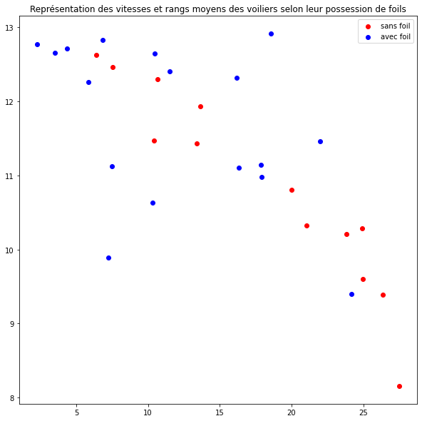

```python
plt.figure(figsize=(10,10))
color = ['r', 'b']
lab = ['sans', 'avec']
for i in [0,1]:
    plt.scatter(df3.loc[i]['Rang'], df3.loc[i]['VMG_last'], c=color[i], label=lab[i]+' foil')
plt.title('Représentation des vitesses et rangs moyens des voiliers selon leur possession de foils')
plt.xlabel=('moyenne du rang')
plt.ylabel=('moyenne de la VMG')
plt.legend()
plt.show()
```